# Agent57: Outperforming the Atari Human Benchmark

[figure not shown]

- Badia, Adrià Puigdomènech, et al. "Agent57: Outperforming the atari human benchmark." International Conference on Machine Learning. PMLR, 2020.
- Presenter: Josh Hernandez

# Outline

- Introduction
  - Reinforcement Learning
- The Environment
- Previous Work
- Contribution of this Paper
- Results
- Topics I Wish I Had More Time to Dig Deeper Into

# Introduction

## Reinforcement Learning

- Reinforcement learning differs from other supervised methods in that you have an interactive-goal seeking ML agent.
- All reinforcement learning agents have explicit goals, can sense aspects of their environments, and can choose actions to influence their environments.

Sutton, Richard S., and Andrew G. Barto. Reinforcement learning: An introduction. MIT press, 2018.

# Elements of Reinforcement Learning

- Agent
- Environment
- Policy
  - learning agent’s way of behaving at a given time
- Reward signal
  - the goal in a reinforcement learning problem
- Value Function
  - total amount of reward an agent can expect to gather in the future, starting from that state
- Internal Model of Environment

# Visualization of Reinforcement Learning

- https://en.wikipedia.org/wiki/File:Reinforcement_learning_diagram.svg

# Example Implementations

- ANN with GA to play Super Mario Bros for the NES
  - https://www.youtube.com/watch?v=CI3FRsSAa_U
- GA used to optimized speed runs in Paper Mario: Thousand Year Door for the Game Cube
  - https://www.youtube.com/watch?v=ywMoHnMpjfo
- AI Plays Hide and Seed (and breaks physics engine)
  - https://www.youtube.com/watch?v=Lu56xVlZ40M
  - https://openai.com/blog/emergent-tool-use/

# The Environment

## Arcade Learning Environment

- Atari 2600 games are well suited for evaluating general competency in AI agents for three main reasons:
  1. they are varied enough to provide multiple different tasks
  2. they are interesting and challenging for humans
  3. they are free of experimenter’s bias, having been developed by an independent party
- https://github.com/mgbellemare/Arcade-Learning-Environment
- M. G. Bellemare, Y. Naddaf, J. Veness and M. Bowling. The Arcade Learning Environment: An Evaluation Platform for General Agents, Journal of Artificial Intelligence Research, Volume 47, pages 253-279, 2013.
- Machado, Marlos C., et al. "Revisiting the arcade learning environment: Evaluation protocols and open problems for general agents." Journal of Artificial Intelligence Research 61 (2018): 523-562.

# Previous Work

## Q Learning

- A model free RL algorithm to learn the value of an action at a particular state.

### Bellman Equation

$$ Q^{new}(s_{t},a_{t}) \leftarrow \underbrace{Q(s_{t},a_{t})}_{\text{old value}} + \underbrace{\alpha}_{\text{learning rate}} \cdot \overbrace{\bigg( \underbrace{\underbrace{r_{t}}_{\text{reward}} + \underbrace{\gamma}_{\text{discount factor}} \cdot \underbrace{\max_{a}Q(s_{t+1}, a)}_{\text{estimate of optimal future value}}}_{\text{new value (temporal difference target)}} - \underbrace{Q(s_{t},a_{t})}_{\text{old value}} \bigg) }^{\text{temporal difference}} $$

- $s_{t+1}=T\left(s_{t},a_{t}\right)$

## Deep Q Network (DQN)

- It's not feasible to keep track of all the states
- Approximate the $Q$ values with a neural network
  - More specifically deep convolutional neural network

### Deep Q Network Visualization

[figure not shown]

Mnih, Volodymyr, et al. "Human-level control through deep reinforcement learning." nature 518.7540 (2015): 529-533.

## Recurrent Replay Distributed DQN (R2D2)

- combining a neural network model with short-term memory and off-policy learning and distributed training to achieving a very strong average performance
  - Kapturowski, Steven, et al. "Recurrent experience replay in distributed reinforcement learning." International conference on learning representations. 2018.

### Distributed Networks

Decouples the data collection and the learning process

- Multiple actors learning from independent copies of the environment and send traning data back to a centeral location
- A learning algorithm can then sample the traning data and learn form it
- Ong, Hao Yi, Kevin Chavez, and Augustus Hong. "Distributed deep Q-learning." arXiv preprint arXiv:1508.04186 (2015).

#### Distributed Networks Visualization

```python
from IPython.display import HTML
display(HTML(open('figures/distributed_agents.svg').read()))
```

[figure not shown]

- Badia, Adrià Puigdomènech, et al. "Agent57: Outperforming the atari human benchmark." International Conference on Machine Learning. PMLR, 2020.

### Short Term Memory

- Recurrent Neural Network
- Hochreiter, Sepp, and Jürgen Schmidhuber. "Long short-term memory." Neural computation 9.8 (1997): 1735-1780.

#### R2D2 Architecture

[figure not shown]

- Badia, Adrià Puigdomènech, et al. "Never give up: Learning directed exploration strategies." arXiv preprint arXiv:2002.06038 (2020).

```python
# https://commons.wikimedia.org/wiki/File:Long_Short-Term_Memory.svg

# from IPython.display import HTML
# display(HTML(open('figures/Long_Short-Term_Memory.svg').read()))
```

## Never Give Up (NGU)

- Exploration
- Episodic Memory
  - $r_t^{\text{intrinsic}} = r_t^{\text{episodic}} \cdot \min\left(\max\left(\alpha_t, 1\right), L\right)$
    - Long-term novelty provided by $\alpha_{t}$
    - $L$, the maximum reward scaling, emprically $L$ chosen to be 5
- Badia, Adrià Puigdomènech, et al. "Never give up: Learning directed exploration strategies." arXiv preprint arXiv:2002.06038 (2020).

# Contribution of this paper

## Agent57

- Meta-controller: learning to balance exploration with exploitation
  - Agent57 is built on the following observation:
    - what if an agent can learn when its better to exploit, and when its better to explore?
  - Two Important Consequences
    - allocate more of the capacity of the network to policies that are most relevant for the task at hand
    - provide a natural way of choosing the best policy in the family to use at evaluation time
- A new parameterization of the state-action value function that decomposes the contributions of the intrinsic and extrinsic rewards.
  - $Q\left(x,a,j; \theta\right) = Q\left(x,a,j; \theta^{\text{extrinsic}}\right) + \beta_{j}Q\left(x,a,j; \theta^{\text{intrinsic}}\right)$
    - $\theta^{\text{extrinsic}}$ and $\theta^{\text{intrinsic}}$ separately parameterize two neural networks with identical architecture.
      - Appendix B of the Agent 57 paper goes through the Extrinsic-Intrinsic Decomposition

## Agent57 Architecture

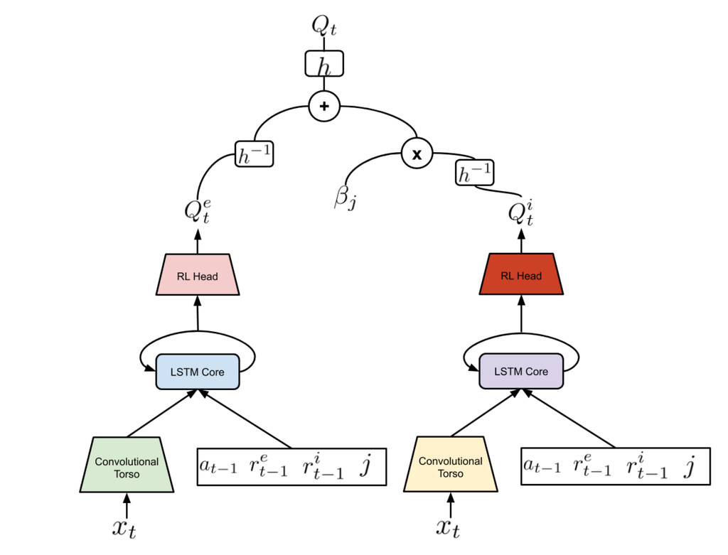

# Results from Paper

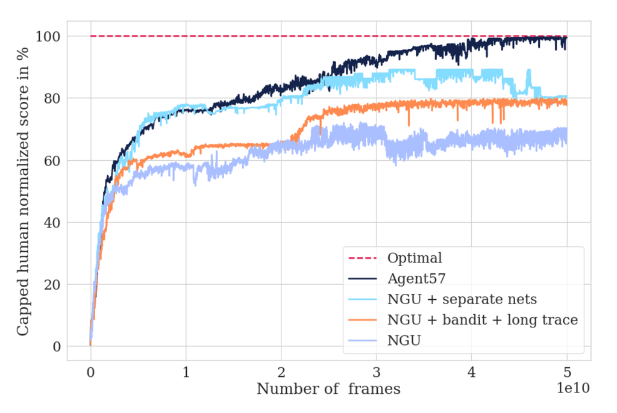

# Topics I Wish I Had More Time to Dig Deeper Into

- Episodic Memory
- Embedding Networks
  - They have embedings to aproximate state so that noveltiy can be measured
  - It wasn't convered much in the paper, so I'll likely have to look else where
- Random Network Distillation
  - Used in the Never Give Up Agent for long term novelty
    - Burda, Yuri, et al. "Exploration by random network distillation." arXiv preprint arXiv:1810.12894 (2018).

# Thanks for Watching

# References

- https://deepmind.com/blog/article/Agent57-Outperforming-the-human-Atari-benchmark
- https://towardsdatascience.com/qrash-course-deep-q-networks-from-the-ground-up-1bbda41d3677
- https://towardsdatascience.com/deep-q-learning-tutorial-mindqn-2a4c855abffc
- https://www.tensorflow.org/agents/tutorials/0_intro_rl

# References

- Badia, Adrià Puigdomènech, et al. "Agent57: Outperforming the atari human benchmark." International Conference on Machine Learning. PMLR, 2020.
- M. G. Bellemare, Y. Naddaf, J. Veness and M. Bowling. The Arcade Learning Environment: An Evaluation Platform for General Agents, Journal of Artificial Intelligence Research, Volume 47, pages 253-279, 2013.
- Machado, Marlos C., et al. "Revisiting the arcade learning environment: Evaluation protocols and open problems for general agents." Journal of Artificial Intelligence Research 61 (2018): 523-562.
- Sutton, Richard S., and Andrew G. Barto. Reinforcement learning: An introduction. MIT press, 2018.
- Kapturowski, Steven, et al. "Recurrent experience replay in distributed reinforcement learning." - - International conference on learning representations. 2018.
- Mnih, Volodymyr, et al. "Human-level control through deep reinforcement learning." nature 518.7540 (2015): 529-533.
- Ong, Hao Yi, Kevin Chavez, and Augustus Hong. "Distributed deep Q-learning." arXiv preprint arXiv:1508.04186 (2015).
- Hochreiter, Sepp, and Jürgen Schmidhuber. "Long short-term memory." Neural computation 9.8 (1997): 1735-1780.
- Badia, Adrià Puigdomènech, et al. "Never give up: Learning directed exploration strategies." arXiv preprint arXiv:2002.06038 (2020).
- Burda, Yuri, et al. "Exploration by random network distillation." arXiv preprint arXiv:1810.12894 (2018).